# HarvardX: PH125.9x Capstone - MovieLens Project

Friederike David

2020-07-31

*This project is part of the* *[HarvardX’s Data Science Capstone](https://www.edx.org/course/data-science-capstone) course,* *which is the last out of nine courses within the* *[HarvardX’s Data Science Professional Certificate](https://www.edx.org/professional-certificate/harvardx-data-science).*

# Introduction

Movie recommendation systems are a common application of machine learning models that aim to predict how a given user would rate a given movie in order to generate recommendations for movies a given user is likely to enjoy. Such recommendation systems are employed for example by streaming services like Netflix to enhance the user experience and therefore well-preforming models can create considerable business value.

In this project, a movie recommendation system based on the [MovieLens 10M Dataset](https://grouplens.org/datasets/movielens/10m/) is implemented, which predicts movie recommendations for a given movie and user within the dataset from a set of input features. The input dataset consists of about 10 million movie ratings with additional information e.g. on movie genre and rating datetime, which are used to build a machine learning model as detailed in the methods sections.

Briefly, as first step the validation subset that is exclusively used for the final model evaluation is derived from the input dataset. The remaining data points are explored and cleaned before deciding on a modelling approach and then further split into a training and test set for model optimization. Finally, model performance will be evaluated in the results section based on the validation set. Both for traning and evaluating the model, the root mean squared error (RMSE) between predicted and true ratings is used as loss function.

# Methods

## Data input

The publicly available [MovieLens 10M Dataset](https://grouplens.org/datasets/movielens/10m/) is downloaded and split into a set for model development (`edx`) and a validation set (`validation`) using a modified version of the R code provided in the course materials. For computational efficiency when re-running the analysis, the downloaded dataset and prepared data objects are saved in `./data/` and re-used if already existing.

## Data exploration and feature engineering

For developing a well-performing machine learning model, it is essential to explore the dataset before deciding on a modeling approach. Therefore, in this section the structure and properties of the training set are examined and potentially relevant input features are prepared.

### Overall structure

```
## Rows: 9,000,055
## Columns: 6
## $ userId    <int> 1, 1, 1, 1, 1, 1, 1, 1, 1, 1, 1, 1, 1, 1, 1, 1, 1, 1, 1, ...
## $ movieId   <dbl> 122, 185, 292, 316, 329, 355, 356, 362, 364, 370, 377, 42...
## $ rating    <dbl> 5, 5, 5, 5, 5, 5, 5, 5, 5, 5, 5, 5, 5, 5, 5, 5, 5, 5, 5, ...
## $ timestamp <int> 838985046, 838983525, 838983421, 838983392, 838983392, 83...
## $ title     <chr> "Boomerang (1992)", "Net, The (1995)", "Outbreak (1995)",...
## $ genres    <chr> "Comedy|Romance", "Action|Crime|Thriller", "Action|Drama|...
```

The training dataset contains 6 columns (userId, movieId, rating, timestamp, title, genres) and 9000055 rows. It comprises 69878 user IDs and 10677 movie IDs/10676 titles as well as 20 genre categories and 797 combinations of one or more genres. Each title also includes the publication year in parentheses.

Trends regarding sparsity within the user ID x movie ID rating matrix are visualized in the following plots.

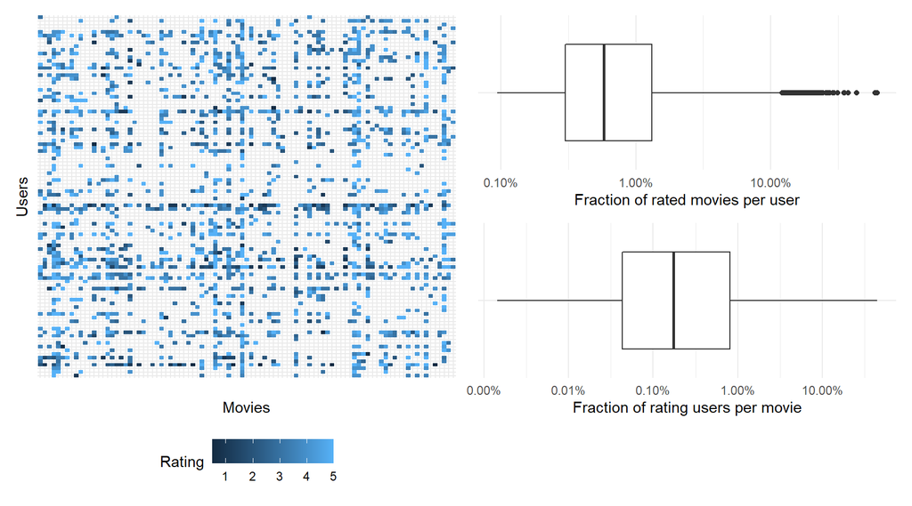

A wide range of rated movies per user and rating users per movie is apparent with some users having rated up to 61.96 % of available movies and some movies having been rated by up to 44.88 % of available users.

### Ratings

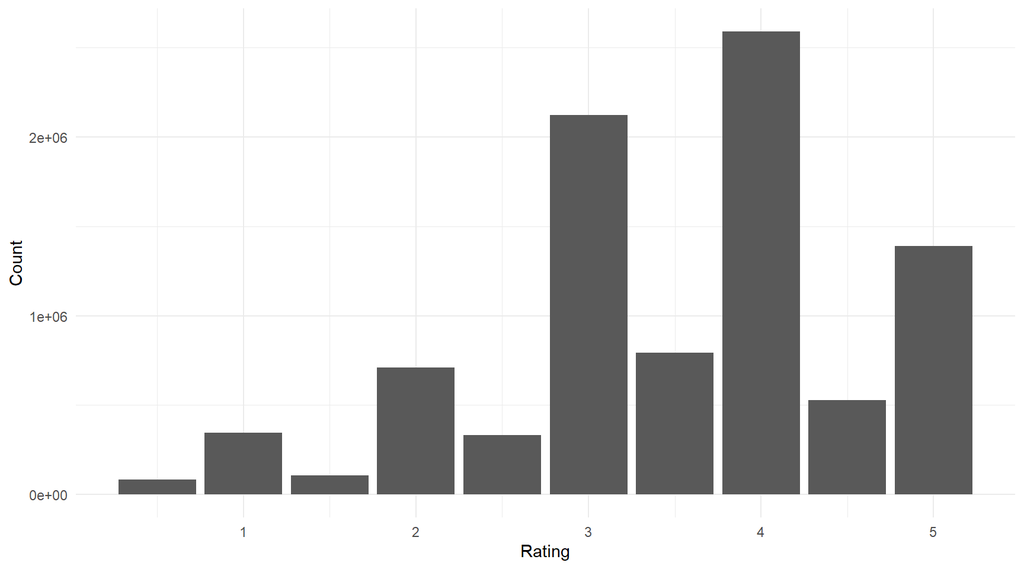

Ratings are recorded within a 5-star system that allows for half-star and full-star ratings. In general, full-star ratings are more common than half-star ratings, although the overall distribution is similar with 4 stars as most frequent full-star rating and 3.5 stars as most frequent half-star rating.

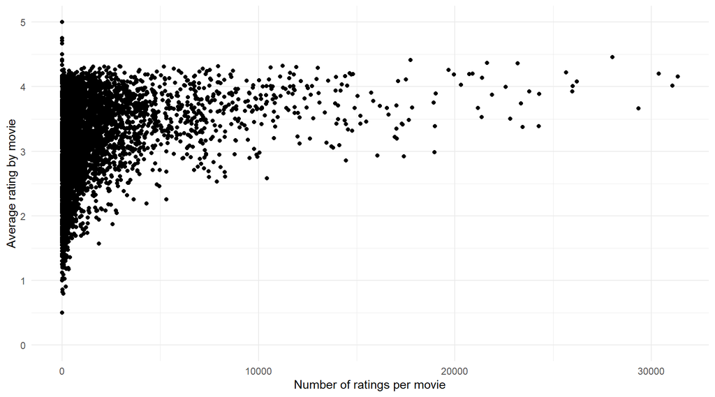

On average, movies with a higher number of ratings, i.e. popular movies, tend to have a higher rating than movies with a low number of ratings, for which a broad range of average ratings is observed.

### Movies

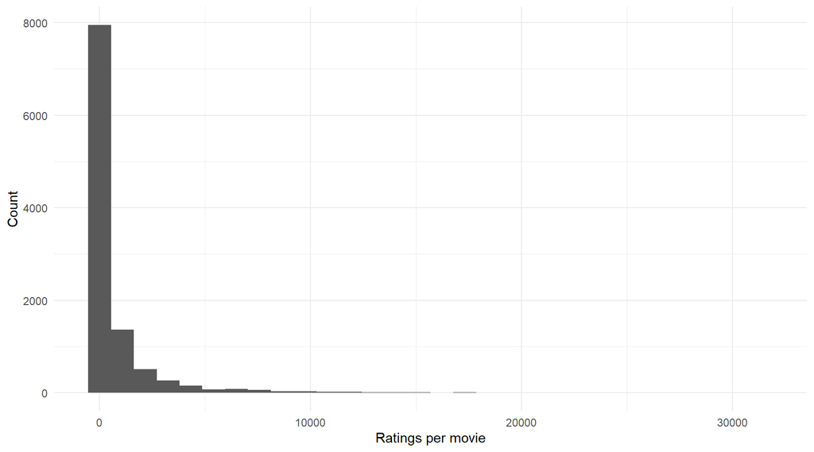

### Users

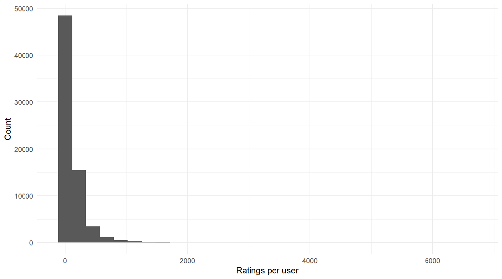

### Genres

| Genre combination | Number of ratings | Mean rating |
| --- | --- | --- |
| (no genres listed) | 7 | 3.642857 |
| Action | 24482 | 2.936321 |
| Action\|Adventure | 68688 | 3.659569 |
| Action\|Adventure\|Animation\|Children\|Comedy | 7467 | 3.962769 |
| Action\|Adventure\|Animation\|Children\|Comedy\|Fantasy | 187 | 2.986631 |

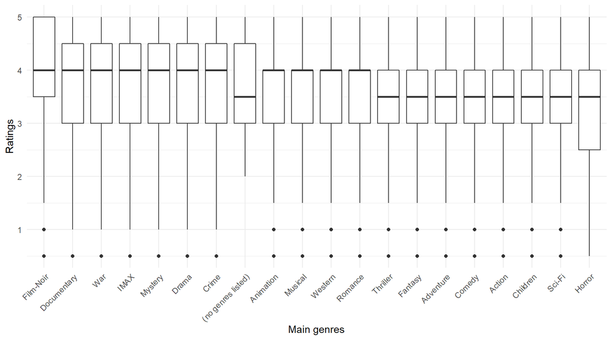

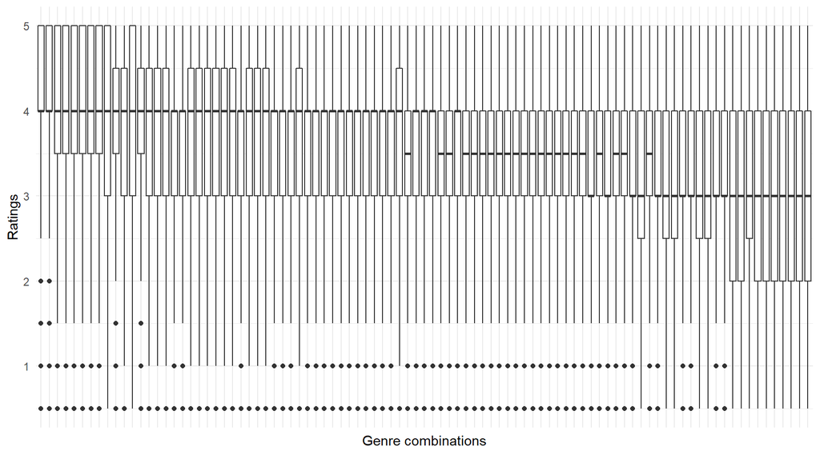

A moderate genre effect on ratings is visible.

### Publication year and rating datetime

Since the datetime of ratings is only given as integer timestamp and the publication year is part of the title, inferred variables are added as possible additional features. Subsequently, time-related trends are visualized in the following plots.

```r
# add publication date extracted from title and rating date, year and weekday
edx <- edx %>%
  mutate(publication_year = str_extract(title, "(?<=\\()[0-9]{4}(?=\\)$)"),
         rating_date = as_datetime(timestamp),
         rating_year = year(rating_date),
         rating_weekday = wday(rating_date, label = T, week_start = 1))
```

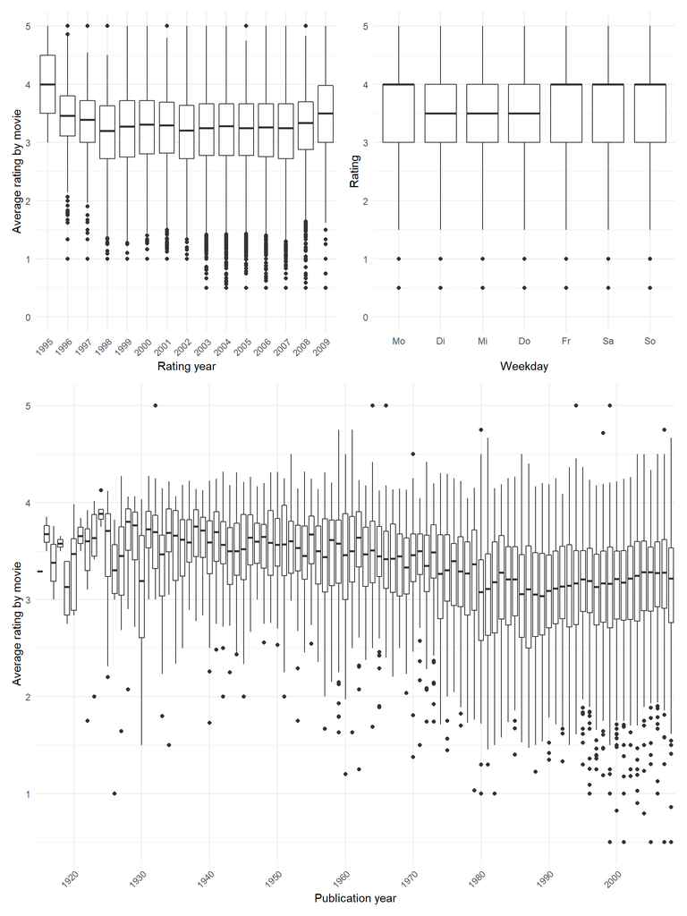

Both publication year and rating year as well as rating weekday seem to have a rather small effect on ratings.

## Model specification

For both parameter optimization and model evaluation, the root mean squared error (RMSE) with predicted ratings $\hat{Y}$, true ratings $Y$ and number of ratings $N$ will be used as loss function:

```r
# function to calculate root mean squared error
RMSE <- function(Y, Y_hat) sqrt(mean((Y - Y_hat)^2))
```

From the preceding data exploration it can be assumed that both movie-specific and user-specific effects are important to model movie ratings. Further, the movie genre may provide some additional information on movie ratings. Rating year, rating weekday and publication year, however, seem to have a negligible impact on ratings and are therefore not included in the model.

The resulting model for movie ratings $Y$ can be written as follows:

$$Y = \mu + b_m + b_u + b_g + \epsilon$$

The formula includes the overall average rating $\mu$ as baseline as well as level-specific feature effects $b$ for movie $m$, user $u$ and movie genre $g$ and an error term $\epsilon$.

As baseline, $\hat{\mu}$ is estimated as the overall average rating.

```r
# estimated mean rating
mu_hat <- mean(edx$rating)
```

$$\hat{b_m} = \frac{1}{n_m}\sum{Y_m - \hat{\mu}}$$
$$\hat{b_u} = \frac{1}{n_u}\sum{Y_u - \hat{\mu} - \hat{b_m}}$$
$$\hat{b_g} = \frac{1}{n_g}\sum{Y_g - \hat{\mu} - \hat{b_m} - \hat{b_u}}$$

```r
movie_basic <- edx %>%
  group_by(movieId) %>% summarize(b_m = mean(rating - mu_hat))

user_basic <- edx %>% left_join(movie_basic) %>%
  group_by(userId) %>% summarize(b_u = mean(rating - mu_hat - b_m))

genre_basic <- edx %>% left_join(movie_basic) %>% left_join(user_basic) %>%
  group_by(genres) %>% summarize(b_g = mean(rating - mu_hat - b_m - b_u))
```

However, since for some movies, users and genres only very few ratings are available, regularization of coefficients is additionally used to improve model performance. Here, the following function will be minimized to obtain the best value for the penalty parameter $\lambda$:

$$\frac{1}{N}\sum{(Y - \mu - b_m - b_u - b_g)^2} + \lambda (\sum{b_m^2} + \sum{b_u^2} + \sum{b_g^2})$$

As in the before in the basic estimation of coefficients, the stepwise approach is employed. Since in the regularization approach $\lambda$ is a tunable parameter, the `edx` set is split into a training and a testing subset to chose the optimal $\lambda$ that minimizes the RMSE in the test set.

```r
# split edx set into training and testing set for model optimization
if (rver < 360) {set.seed(1)} else {set.seed(1, sample.kind = "Rounding")}
train_index <- createDataPartition(edx$rating, p = 0.9, list = F)

train <- edx[train_index,]
tmp <- edx[-train_index,]

# make sure userId and movieId in test set are also in train set
test <- semi_join(tmp, train, by = "movieId") %>% semi_join(train, by = "userId")

# add rows removed from test set back into train set
train <- rbind(train, anti_join(tmp, test))
```

Using the `train` set to calculate regularized coefficients at different values for $\lambda$ and the `test` set to calculate the corresponding RMSE, the optimal value for $\lambda$ that minimizes the RMSE on the test set is selected.

```r
# calculate RSME at different lambdas (regularizing movie, user and genre regects)
lambdas <- seq(0, 15, 0.5)
rmse_reg <- sapply(lambdas, function(lambda) {

  # regularized movie effects
  movie_reg <- train %>%
    group_by(movieId) %>%
    summarize(b_m = sum(rating - mu_hat)/(lambda + n()))

  # regularized user effects
  user_reg <- train %>%
    left_join(movie_reg, by = "movieId") %>%
    group_by(userId) %>%
    summarize(b_u = sum(rating - mu_hat - b_m)/(lambda + n()))

  # regularized genre effects
  genre_reg <- train %>%
    left_join(movie_reg, by = "movieId") %>%
    left_join(user_reg, by = "userId") %>%
    group_by(genres) %>%
    summarize(b_g = sum(rating - mu_hat - b_m - b_u)/(lambda + n()))

  # RSME estimation for test set
  test %>%
    left_join(movie_reg, by = "movieId") %>%
    left_join(user_reg, by = "userId") %>%
    left_join(genre_reg, by = "genres") %>%
    mutate(rating_hat = mu_hat + b_m + b_u + b_g) %>%
    summarize(rmse = RMSE(rating, rating_hat)) %>%
    pull(rmse)
})
```

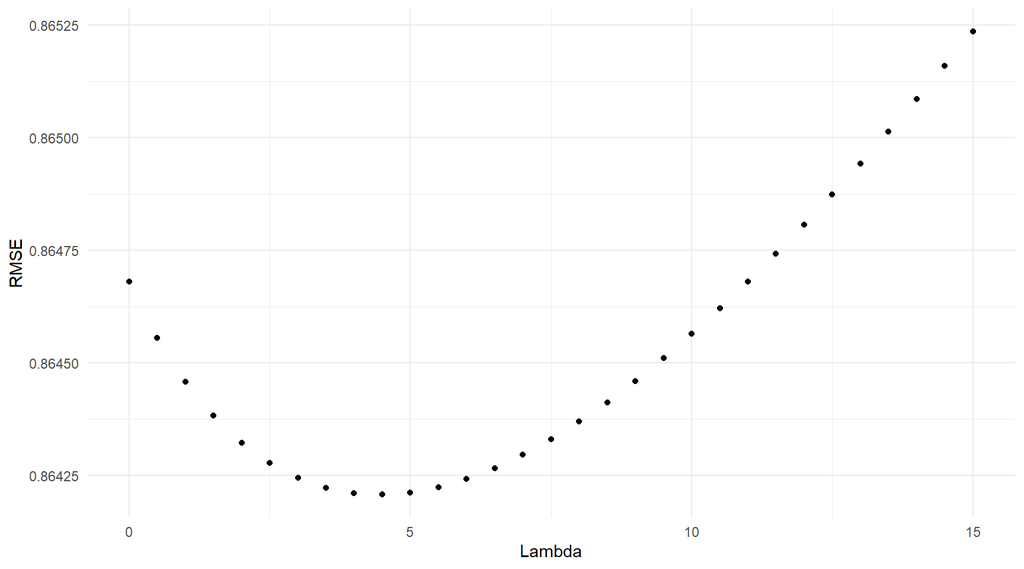

With this optimal value for $\lambda$, the final regularized model coefficients are calculated.

```r
# get coefficients for lambda that minimizes the RSME
lambda <- lambdas[which.min(unlist(rmse_reg))]

# calculate the corresponding coefficients for the entire edx set
movie_reg <- edx %>%
  group_by(movieId) %>%
  summarize(b_m = sum(rating - mu_hat)/(lambda + n()))
user_reg <- edx %>%
  left_join(movie_reg, by = "movieId") %>%
  group_by(userId) %>%
  summarize(b_u = sum(rating - mu_hat - b_m)/(lambda + n()))
genre_reg <- edx %>%
  left_join(movie_reg, by = "movieId") %>%
  left_join(user_reg, by = "userId") %>%
  group_by(genres) %>%
  summarize(b_g = sum(rating - mu_hat - b_m - b_u)/(lambda + n()))
```

# Results

After fitting the basic and regularized models as described, performance is evaluated by calculating the RMSE on the validation set. Additionally, the RMSE obtained when using the overall average rating as naive prediction is included.

```r
# naive prediction with overall mean
rmse_naive_mean <- RMSE(validation$rating, mu_hat)

# basic model
rmse_basic <- validation %>%
  left_join(movie_basic) %>%
  left_join(user_basic) %>%
  left_join(genre_basic) %>%
  mutate(rating_hat = mu_hat + b_m + b_u + b_g) %>%
  summarize(rmse = RMSE(rating, rating_hat)) %>%
  pull(rmse)

# regularized model
rmse_regularized <- validation %>%
  left_join(movie_reg, by = "movieId") %>%
  left_join(user_reg, by = "userId") %>%
  mutate(rating_hat = mu_hat + b_m + b_u) %>%
  summarize(rmse = RMSE(rating, rating_hat)) %>%
  pull(rmse)

data.frame(Model = c("naive mean", "simple additive model", "regularized model"),
           RMSE = c(rmse_naive_mean, rmse_basic, rmse_regularized)) %>%
  knitr::kable(caption = "RSME estimates for different modelling approaches")
```

RSME estimates for different modelling approaches

| Model | RMSE |
| --- | --- |
| naive mean | 1.0612018 |
| simple additive model | 0.8649469 |
| regularized model | 0.8648242 |

# Conclusion